# Знакомство с многомерными данными

## Вы сможете

- Объяснить почему для некоторых задач больше подходят многомерные данные
- Объяснить суть понятия "многомерное пространство признаков"
- Представить многомерные данные в виде матриц описания значений признаков для объектов
- Оценить сходство/различие между объектами с помощью специальных коэффициентов
- Описать *взаиморасположение* объектов многомерном пространстве признаков с помощью матриц
- Визуализировать взаиморасположение объектов с помощью простейших методов

## Общая характеристика многомерных методов

## Почему нужны многомерные методы?

Пусть у нас имеется две группы объектов, у которых мы изучили некий признак. Мы хотим тестировать гипотезу о том, что эти две группы различаются.

Вспомним логику тестирования гипотез.

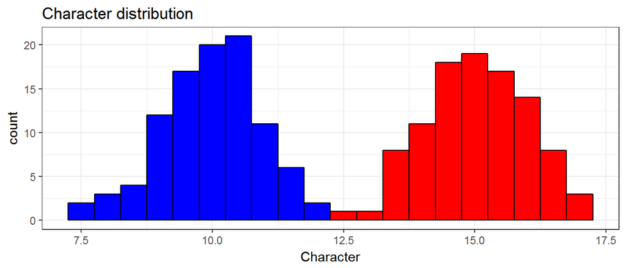

## Почему нужны многомерные методы?

Теперь представим, что наш объект, по своей природе, не может быть описан только по одному признаку

- Сообщества (признаки - виды)
- Форма тела (признаки - размеры тех или иных частей)
- Социальная активность животного (признаки - проявление того или иного паттерна)
- Общественное мнение (признаки - ответы на разные вопросы анкет)
- Транскриптом (признаки - транскрипты)

## Почему нужны многомерные методы?

Предположим, что объекты характеризуются только двумя признаками

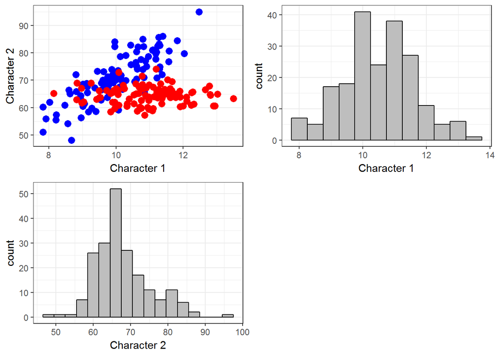

## Какие задачи решаются методами могомерной статистики?

- Выявление взаимоотношений (сходства-различия) между объектами (или признаками):
- Классификация (Кластерный анализ)
- Ординация. В том числе каптирование пространственно выраженных объектов (nMDS, PCA, RDA).
- Тестирование гипотез о различиях между группами объектов (ANOSIM, PERMANOVA).
- Выявление связи между группами признаков (тест Мантела, BIOENV, CCA).

## Признаки и объекты

Данные представляются в виде таблицы (матрицы), где строками являются объекты (Objects), а столбцами признаки (Descriptors).

## R и Q анализы

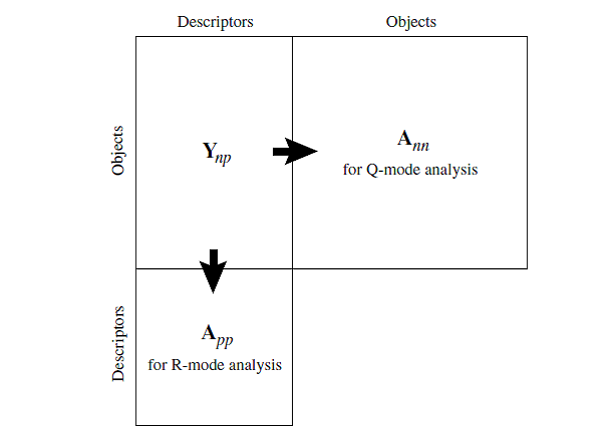

R и Q

- R-анализ: Выясняем взаимоотношения между признаками
- Q-анализ: Выясняем взаимоотношения между объектами

## Геометрическая интерпретация Q-анализа

- Признаки - оси
- Объекты - точки

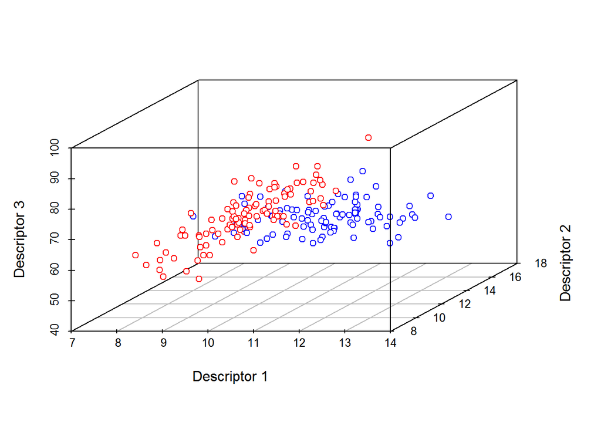

## Описание расположения объектов в многомерном пространстве признаков

В большинстве случаев нас интересуют не абсолютные значения координат (признаков), а *взаиморасположение* точек в многомерном пространстве.

Существует два основных способа описания.

## Способ 1. Геометрическое описание (линейная алгебра)

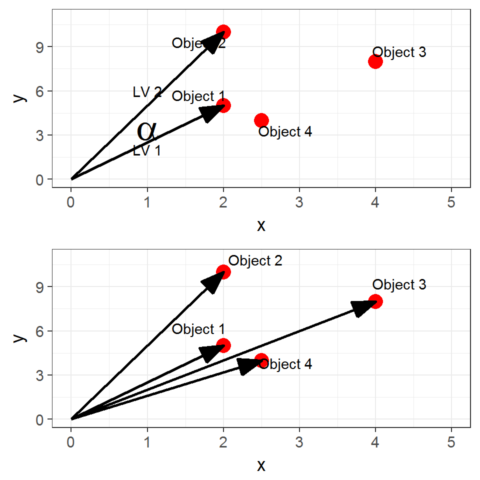

Для описания взаиморасположения точек необходимо иметь два набора данных

Матрицу углов между векторами (косинусов углов)

\[\begin{pmatrix} \alpha_{11} & \alpha_{12} & \cdots & \alpha_{1n} \\ \alpha_{21} & \alpha_{22} & \cdots & \alpha_{2n} \\ \vdots & \vdots & \ddots & \vdots \\ \alpha_{n1} & \alpha_{n2} & \cdots & \alpha_{nn} \end{pmatrix}\]

Ряд длин векторов \[\begin{vmatrix} LV1 \\ LV2 \\ ... \\ LVn \end{vmatrix}\]

Этот способ описания, с разными вариациями, будет применяться в методах *PCA, CCA, RDA*

## Способ 2. Через вычисление матрицы попарных расстояний (Similarity/Dissimilarity matrix)

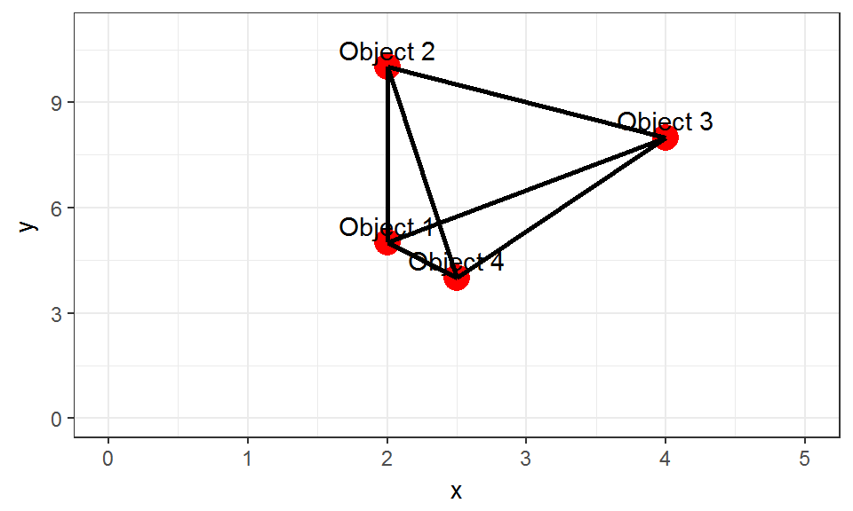

В анализ вовлекается матрица попарных расстояний (сходств) между объектами. Эта матрица однозначно описывает взаиморасположение между объектами.

Этот способ представления взаиморасположения лежит в основе *Иерархического кластерного анализа, MDS, теста Мантела, ANOSIM, PERMANOVA, процедуры BIOENV*

## Три способа изображения матрицы расстояний

```
##     1   2   3   4
## 1 0.0 5.0 3.6 1.1
## 2 5.0 0.0 2.8 6.0
## 3 3.6 2.8 0.0 4.3
## 4 1.1 6.0 4.3 0.0
```

```
##     1   2   3   4
## 1 0.0
## 2 5.0 0.0
## 3 3.6 2.8 0.0
## 4 1.1 6.0 4.3 0.0
```

```
##     1   2   3
## 2 5.0
## 3 3.6 2.8
## 4 1.1 6.0 4.3
```

Количество чисел в треугольной матрице сходства/различия:

\[N = \frac{n^2 - n}{2}\]

## Матрица расстояний в развернутом виде (Unfolded similarity/dissimilarity matrix)

```
##     1   2   3
## 2 5.0
## 3 3.6 2.8
## 4 1.1 6.0 4.3
```

```
## [1] 5.0 3.6 1.1 2.8 6.0 4.3
```

## Меры сходства и различия между объектами (Resemblance coefficients)

## Кто что ест? Потребление белка разного происхождения в Европе

9 признаков 25 объектов:

- Country: Страна
- RdMeat: Красное мясо
- WhMeat: Белое мясо
- Eggs: Яйца
- Milk: Молоко
- Fish: Рыба
- Cereal: Зерновые культуры
- Starch: Крахмал-содержащая пища
- Nuts: Бобовые, орехи и масличные культуры
- Fr&Veg: Фрукты и овощи

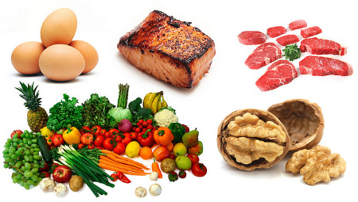

Paleo Diet by zsoolt

Paleo Diet by zsoolt on [Flickr](https://flic.kr/p/pPK1nz)

## Читаем данные

```r
protein <- read.table("data/Protein.txt", header = TRUE, sep = "\t")
head(protein)
```

```
##          Country RedMeat WhiteMeat Eggs Milk Fish Cereals Starch Nuts
## 1        Albania    10.1       1.4  0.5  8.9  0.2    42.3    0.6  5.5
## 2        Austria     8.9      14.0  4.3 19.9  2.1    28.0    3.6  1.3
## 3        Belgium    13.5       9.3  4.1 17.5  4.5    26.6    5.7  2.1
## 4       Bulgaria     7.8       6.0  1.6  8.3  1.2    56.7    1.1  3.7
## 5 Czechoslovakia     9.7      11.4  2.8 12.5  2.0    34.3    5.0  1.1
## 6        Denmark    10.6      10.8  3.7 25.0  9.9    21.9    4.8  0.7
##   Fr.Veg
## 1    1.7
## 2    4.3
## 3    4.0
## 4    4.2
## 5    4.0
## 6    2.4
```

## Подготовка данных для анализа

Переменные могут быть измерены в разных шкалах

- численность, биомасса и проективное покрытие организмов
- температура воды, соленость и концентрация биогенов
- Размеры частей тела, количество частей тела, площадь частей тела

Для таких случаев необходима стандартизация величин.  
Этот прием наиболее важен для геометрического способа представления многомерных данных.

\[x_{stand} = \frac{x_i - \bar{x}}{\sigma_x}\]

- **Вопрос:** Какими свойствами обладают стандартизованные величины?
- Среднее значение равно нулю.
- Среднеквадратичное отклонение равно единице.

## Подготовка данных для анализа

В ряде случаев (особенно в экологических исследованиях) необходимо перевести абсолютные значения в относительные (доли от суммы или от максимума)

\[x_{rel} = \frac{x_i}{\sum x_i} \times 100 \%\]

\[x_{rel} = \frac{x_i}{max(x_i)} \times 100 \%\]

## Подготовка данных для анализа

Часто возникает ситуация, когда один признак (или несколько признаков) имеет существенно более высокие абсолютные значения, чем все остальные.

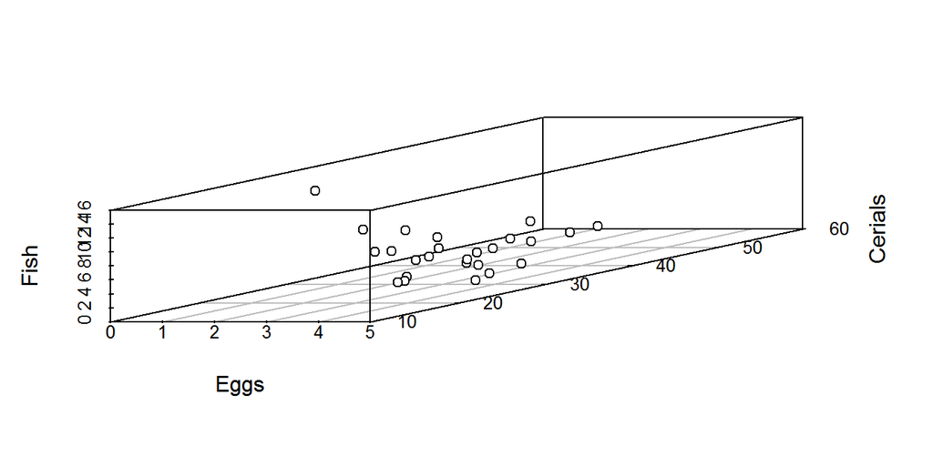

В такой ситуации необходима *трансформация* , которая "уравнивает" силу влияния признаков.

По силе эффекта трансформирующие функции распределяются так:

Отсутствие трансформации \(\Rightarrow\) Квадратный корень \(\Rightarrow\) Корень четвертой степени \(\Rightarrow\) Логарифм \(log(x_i +1)\) \(\Rightarrow\) Присутствие отсутствие (1, 0)

## Задание:

На основе датасета `protein` создайте матрицу, содержащую относительные величины (доли протеина каждого типа в общей количестве потребляемых протеинов)

Hint: Воспользуйтесь функцией `apply()`

## Решение

```r
total <- apply(protein[, -1], MARGIN = 1,FUN = sum)
protein_stand <- protein[, -1] / total
protein_stand$Country <- protein$Country

head(protein_stand)
```

```
##   RedMeat WhiteMeat    Eggs   Milk    Fish Cereals  Starch   Nuts
## 1  0.1419    0.0197 0.00702 0.1250 0.00281   0.594 0.00843 0.0772
## 2  0.1030    0.1620 0.04977 0.2303 0.02431   0.324 0.04167 0.0150
## 3  0.1546    0.1065 0.04696 0.2005 0.05155   0.305 0.06529 0.0241
## 4  0.0861    0.0662 0.01766 0.0916 0.01325   0.626 0.01214 0.0408
## 5  0.1171    0.1377 0.03382 0.1510 0.02415   0.414 0.06039 0.0133
## 6  0.1180    0.1203 0.04120 0.2784 0.11024   0.244 0.05345 0.0078
##   Fr.Veg        Country
## 1 0.0239        Albania
## 2 0.0498        Austria
## 3 0.0458        Belgium
## 4 0.0464       Bulgaria
## 5 0.0483 Czechoslovakia
## 6 0.0267        Denmark
```

## Наиболее частые коэффиценты сходства/различия и расстояния

Знакомимся с пакетом `{vegan}` (Oksanen et al., 2015)

```
##        1     2     3     4     5     6     7     8     9    10    11
## 2  23.18
## 3  21.65  7.87
## 4  15.69 32.30 32.79
## 5  15.15 10.31 10.61 24.01
## 6  30.16 11.96 11.12 40.33 19.42
## 7  22.87 10.74  8.93 33.61 10.61 15.18
## 8  30.99 17.42 17.60 40.34 24.02 12.25 23.83
## 9  23.17 11.01  6.01 33.26 13.44 12.72 13.86 18.18
## 10 12.14 19.53 18.25 19.32 15.03 24.47 22.11 24.11 18.25
## 11 13.16 16.97 18.78 18.40  9.18 26.73 17.52 29.98 21.26 14.93
## 12 27.90 10.04  9.15 38.36 17.58  8.94 16.18 11.57 10.15 22.98 25.02
## 13 10.62 14.69 13.57 21.01  8.71 21.60 15.62 23.76 15.16  7.98 10.70
## 14 28.30  6.76  9.68 38.53 16.35  8.36 13.27 14.68 12.35 24.06 23.21
## 15 26.81 13.68 10.80 38.17 18.73  6.69 14.99 11.69 13.15 21.42 25.67
## 16 17.64  9.94 12.20 24.49  8.26 17.81 14.87 19.36 14.01 12.36 11.99
## 17 23.11 22.93 19.20 33.29 19.06 23.93 15.16 31.18 21.85 22.16 22.03
## 18 10.32 25.26 25.88  8.33 17.31 33.29 26.73 33.40 27.12 13.34 11.64
## 19 17.15 17.44 13.92 28.89 13.07 21.19 11.78 26.57 17.22 16.27 16.17
## 20 29.99 13.03 11.63 41.48 20.43  4.80 15.58 11.91 14.03 25.16 27.66
## 21 24.93  7.58  7.53 35.51 14.97  9.65 14.65 13.05  8.18 20.04 22.14
## 22 24.31 12.92  6.83 36.42 16.50 11.74 14.78 15.95  6.99 20.32 24.17
## 23 11.03 19.04 18.42 16.68 12.64 25.33 21.37 24.69 19.43  8.18 12.49
## 24 29.14 10.13  9.07 40.62 17.15  9.90 10.56 18.88 12.46 26.28 24.70
## 25 15.47 31.95 32.68  4.88 23.98 39.87 33.28 39.33 33.72 18.75 17.62
##       12    13    14    15    16    17    18    19    20    21    22
## 2
## 3
## 4
## 5
## 6
## 7
## 8
## 9
## 10
## 11
## 12
## 13 20.04
## 14  6.83 19.87
## 15 10.88 18.77 11.55
```

[output cut: 20 more lines]

```
## 11
## 12
## 13
## 14
## 15
## 16
## 17
## 18
## 19
## 20
## 21
## 22
## 23
## 24 26.58
## 25 15.79 40.28
```

## Сходства и различия

- Сходство (S) достигает максимума, когда объекты обладают идентичными признаками, различиe (D), наоборот - достигает минимума.
- Обычно (но не всегда) коэффициенты сходства распределены от 0 до 1.
- Тогда \(D = 1 - S\), или \(D = \sqrt{1 - S}\), или \(D = \sqrt{1-S^2}\).
- Показатели расстояния можно нормировать. \(D_{norm} = \frac{D}{D_{max}}\), или \(D_{norm} = \frac{D - D_{min}}{D_{max} - D_{min}}\).

## Проблема двойных нулей (Double zeros probem)

```
##         D1 D2 D3 D4 D5 D6 D7 D8 D9 D10
## Object1  0  0  0  0  0  0  0  2  2   1
## Object2  0  0  0  0  0  4  5  0  0   1
```

О чем говорит то, что признаки D1, D2, D3, D4, D5 не были отмечены у двух объектов?

- Вариант 1. Это ничего не означает.
- Вариант 2. Отсутствие признака - дополнительное сходство между объектами.

От ответа на этот вопрос зависит какой коэффициент выбрать.

## Два типа коэффициентов

Меры сходства/различия не учитывающие двойные нули. Эти коэффициенты не изменяются если в данные будут добавлены двойные нули (например, при увеличении количества описанных объектов).

Примеры:

- Евклидово расстояние
- расстояние по Манхеттену.

Меры сходства/различия учитывающие двойные нули. Эти коэффициенты изменяются при появлении двойных нулей. Сходство возрастает за счет того, что отсутствие признака считается тоже сходством.

Пример:

- Коэффициенты корреляции.

## Меры расстояния, или метрики

Свойства:

- Если \(a = b\), то \(D(a, b) = 0\)
- Симметричность \(D(a, b) = D(b, a)\)
- Справедливо неравенство треугольника \(D(a,b) + D(b,c) \geq D(a,c)\)

## Наиболее популярные меры расстояния

*Важно:* метрики неадекватно оценивают степень различия при большом количестве нулей.Очень чувствительны к выбросам.

**Нестандартизованные**

- Евклидово расстояние:

\[D = \sqrt{\sum(x_{i,j} - x_{i,k})^2}\]

- Расстояние по Манхеттену (Manhattan metric, taxicab metric, city-block metric):

\[D = \sum \mid x_{i,j} - x_{i,k} \mid\]

**Стандартизованные**

Удобнее так как признаки могут быть измерены в разных шкалах

- Расстояние по Канберре (Canberra metric):

\(D = \frac{1} {p} \sum \frac {\mid x_{i,j} - x_{i,k} \mid} {x_{i,j}+ x_{i,k}}\)

- Расстояние \(\chi^2\)

\(\chi^2 = \sqrt{ \sum {\frac{1}{c_i}} (x_{i,j} - x_{i,k})^2}\)

- Евклидово расстояние, вычисленное по относительным величинам.

## Неметрические коэффициенты сходства/различия (Similarity/Dissimilarity)

- Корреляция Браве-Пирсона: \[ R = \frac {cov(X, Y)}{\sqrt{\sigma_x^2\sigma_y^2}} \]

Коэффициент Браве-Пирсона варьирует от -1 до 1.

Обычно используется в R анализе

- Коэффициент Брея-Куртиса (Bray-Curtis dissimilarity): \[D = \frac{\sum \mid x_{i,j} - x_{i,k} \mid} {\sum x_{i,j} + \sum x_{i,k}}\]

Это самый распространенный в экологии коэффициент.

## Коэффициенты для бинарных данных

В основе лежит четырехпольная таблица

\[\begin{vmatrix} \, & + & - \\ + & a & b \\ - & c & d \end{vmatrix}\]

- a - сходство объектов по наличию признака
- b - различие
- c - различие
- d - сходство по отсутствию признака

## Коэффициенты для бинарных данных

- Доля несовпадений:

\[D = \frac{b+c}{a+b+c}\]

- Коэффициент Жаккара:

\[S = \frac{a}{a+b+c}\]

- Коэффициент Сёренсена:

\[S = \frac{2a}{2a + b + c}\]

*NB!* Коэффициент Сёренсена - это коэффициент Брея-Куртиса, вычисленный для значений, оцененных как 1 или 0.

## Коэффициенты для бинарных данных

- \(\phi\)-корреляция Пирсона

\[\phi = \frac{ad-bc}{(a+b)(c+d)(a+c)(b+d)}\]

Используется в R-анализе

## Коэффициент Говера

Обобщенный коэффициент, который применяется для случаев, когда одни признаки объекта описаны, как количественные величины, а другие - как бинарные данные (или даже качественные данные).

\[ D = \frac{1}{p} \frac{\sum W_i\dfrac{\mid x_{i,j} - x_{i,k} \mid}{\max x_{i,j} - \min x_{i,k}}}{\sum W_i}\]

\(W_i\) = 0 Если отсутствует информация o \(x_{i,j}\) и/или \(x_{i,k}\) отсутствует  
\(W_i\) = 1 Если присутствует информация как о \(x_{i,j}\) так и о \(x_{i,k}\)

## Отчего зависит выбор коэффициента?

1. От природы материала (признаки могут иметь количественную, бинарную и качественную оценку).
2. От характера тестируемой гипотезы (какой аспект природы сходства-различия хочет выразить автор).
3. В экологии: от того, насколько мы хотим учитывать вклад редких и малочисленных видов.
4. От взглядов исследователя на природу сходства/различия между объектами.
5. От типа анализа (R или Q)

## Многие показатели взаимосвязаны и, часто, взаимозаменяемы

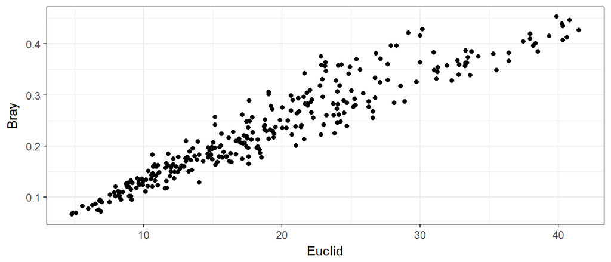

```r
BCD <- as.vector(vegdist(protein[,-1], method = "bray"))
ED <- as.vector(vegdist(protein[,-1], method = "euclidean"))

distances <- data.frame(Bray = BCD, Euclid = ED)
ggplot(distances, aes(x = Euclid, y = Bray)) + geom_point() + theme_bw()
```

## Какую информацию мы можем извлечь из матрицы расстояний?

Самый простой анализ - частотное распределение расстояний  
Позволяет понять есть ли сгущения в облаке точек в n-мерном пространстве признаков

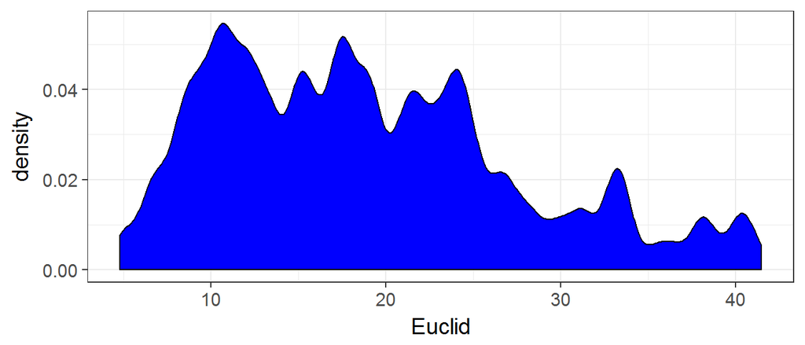

```r
ggplot(distances, aes(x = Euclid)) + stat_density(adjust = 1/4, geom = "area", fill = "blue", color = "black")
```

## Какую информацию мы можем извлечь из матрицы расстояний?

Для более детального извлечения информации из матрицы расстояний необходимо перейти к рассмотрению техники ординации.

## Summary

- Существует два подхода к анализу многомерных данных:
- подход, основанный на линейной алгебре,
- подход, основанный на исследовании матриц сходства/различия между объектами.
- Выбор коэффициентов сходств/различия - непростая задача, решение которой зависит от структуры материала и поставленных задач. Разные коэффициенты потенциально могут давать разные результаты.
- Получить важную информацию о взаиморасположении объектов можно с помощью некоторых простейших методов.

## Что почитать

- Legendre P., Legendre L. (1998) Numerical ecology. Second english edition. Elsevier, Amsterdam. (Фундаментальный труд, описывающий большинство методов. Дается исчерпывающее обсуждение разнообразных коэффициентов сходства/различия)
- Zuur, A. F., Ieno, E. N., Smith, G. M. Analysing Ecological Data. Springer 2007 (Практичеки все то же самое, что в L&L, но написанное простым языком)
- Clarke, K. R., Gorley R. N. (2006) PRIMER v6: User Manual/Tutorial. PRIMER-E, Plymouth. (Очень доходчиво написанное руководство, дающее общее представление о "механике" работы многомерных методов)
- Миркин Б.М., Розенберг Г.С. Фитоценология. Принципы и методы. М., 1978. (Руководство написано в докомпьютерную эпоху, но простейшие методы изложены очень хорошо)
- Василевич В.И. Статистические методы в геоботанике. - Л.: Наука, 1969.
- Дюран Б., Оделл П. Кластерный анализ. М.: Статистика, 1977